# 📊 Classificação de Rentabilidade de Vendas

## 1. Introdução

Este projeto desenvolve um modelo de aprendizado de máquina supervisionado para classificar transações de vendas de acordo com sua rentabilidade

O objetivo principal é responder à seguinte questão de negócio:

Podemos prever se uma transação de vendas será lucrativa com base em suas características comerciais, operacionais e do cliente?

O conjunto de dados contém informações sobre:

- Orders
- Customers
- Products
- Regions and countries
- Quantities
- Unit prices
- Discounts
- Sales
- Shipping costs
- Profit
- Payment methods

A variável-alvo será derivada da coluna `Profit`:

- `1` → Venda rentável
- `0` → Venda não rentável

O objetivo não é apenas construir um modelo preditivo, mas também entender quais características das vendas estão associadas à rentabilidade.

## 2. Bibliotecas

```python
import numpy as np                                     # Biblioteca para operações matemáticas.
import pandas as pd                                    # Biblioteca de manipulação de dados.

import matplotlib.pyplot as plt                        # Biblioteca para criação de gráficos.
import seaborn as sns                                  # Biblioteca para criação de gráficos.

from sklearn.compose import ColumnTransformer          # Permite aplicar transformações diferentes para diferentes colunas.
from sklearn.dummy import DummyClassifier              # Modelo simples e rápido de construir que serve como ponto de partida e referência de desempenho.
from sklearn.ensemble import RandomForestClassifier    # Algoritmo de classificação baseado em várias árvores de decisão.
from sklearn.impute import SimpleImputer               # Utilizado para tratar valores ausentes.
from sklearn.linear_model import LogisticRegression    # Algoritmo clássico de classificação.
from sklearn.metrics import (                          # Métricas para avaliar o modelo.
    accuracy_score,                                    # Mede a proporção de previsões corretas.
    classification_report,                             # Maneira prática de visualizar várias métricas de uma vez.
    confusion_matrix,                                  # Matriz de confusão.
    ConfusionMatrixDisplay,                            # Usado para mostrar visualmente a matriz de confusão.
    f1_score,                                          # Útil quando queremos equilibrar Precision e Recall.
    precision_score,                                   # Das vendas que o modelo classificou como rentáveis, quantas realmente eram rentáveis?
    recall_score,                                      # Das vendas realmente rentáveis, quantas o modelo conseguiu identificar?
    roc_auc_score,                                     # Mede a capacidade do modelo de distinguir: lucrativa e não lucrativa.
    RocCurveDisplay,                                   # Utilizado para visualizar a curva ROC.
)
from sklearn.model_selection import (                  # Ferramentas relacionadas à separação dos dados e validação dos modelos.
    StratifiedKFold,                                   # É uma estratégia de Cross-Validation estratificada.
    cross_validate,                                    # Executa a validação cruzada. Isso permite avaliar o modelo em diferentes divisões dos dados.
    train_test_split,                                  # Divide os dados em treino e teste.
)
from sklearn.pipeline import Pipeline                  # Ele permite juntar várias etapas: Isso deixa o código mais organizado e ajuda a evitar data leakage durante o pré-processamento.
from sklearn.preprocessing import (
    OneHotEncoder,                                     # Transforma variáveis categóricas em variáveis numéricas.
    StandardScaler,                                    # Padroniza variáveis numéricas.
)
from sklearn.tree import DecisionTreeClassifier        # Árvore de decisão para classificação.
```

## 3. Configuração visual

```python
# Configuração básica para melhorar a visualização dos gráficos.
sns.set_theme(style="whitegrid")
plt.rcParams["figure.figsize"] = (14, 4)
pd.set_option(
    "display.max_columns",
    None,
)
```

## 4. Carregando os dados

```python
# Caminho do conjunto de dados
DATA_PATH = "/kaggle/input/datasets/jcarlossc/global-sales/global_ecommerce_sales.csv"
```

```python
# Leitura do conjunto de dados
data = pd.read_csv(DATA_PATH)
```

```python
# Apresentação dos três primeiros registros
data.head(3)
```

|  | Order_ID | Order_Date | Customer_Name | Customer_Segment | Country | Region | Product_Category | Product_Name | Quantity | Unit_Price | Discount_Percent | Total_Sales | Shipping_Cost | Profit | Payment_Method |
| --- | --- | --- | --- | --- | --- | --- | --- | --- | --- | --- | --- | --- | --- | --- | --- |
| 0 | ORD-11121 | 2023-01-02 | Karen Suzuki | Corporate | United States | North America | Technology | Wireless Bluetooth Headphones | 3 | 99.43 | 0 | 298.29 | 9.31 | 124.92 | Cash on Delivery |
| 1 | ORD-11244 | 2023-01-02 | John Johansson | Corporate | Spain | Europe | Technology | Mechanical Gaming Keyboard | 4 | 97.93 | 20 | 313.38 | 14.31 | 83.62 | Cash on Delivery |
| 2 | ORD-10325 | 2023-01-03 | Jessica Garcia | Consumer | Mexico | North America | Office Supplies | Binder Clips Assorted 48pc | 2 | 10.74 | 0 | 21.48 | 8.12 | 3.69 | Credit Card |

## 5. Informações gerais

```python
# Dimensões
data.shape
```

```
(2000, 15)
```

```python
# Lista das colunas
data.columns.tolist()
```

```
['Order_ID',
 'Order_Date',
 'Customer_Name',
 'Customer_Segment',
 'Country',
 'Region',
 'Product_Category',
 'Product_Name',
 'Quantity',
 'Unit_Price',
 'Discount_Percent',
 'Total_Sales',
 'Shipping_Cost',
 'Profit',
 'Payment_Method']
```

```python
# Informações do conjunto de dados
data.info()
```

```
<class 'pandas.core.frame.DataFrame'>
RangeIndex: 2000 entries, 0 to 1999
Data columns (total 15 columns):
 #   Column            Non-Null Count  Dtype
---  ------            --------------  -----
 0   Order_ID          2000 non-null   object
 1   Order_Date        2000 non-null   object
 2   Customer_Name     2000 non-null   object
 3   Customer_Segment  2000 non-null   object
 4   Country           2000 non-null   object
 5   Region            2000 non-null   object
 6   Product_Category  2000 non-null   object
 7   Product_Name      2000 non-null   object
 8   Quantity          2000 non-null   int64
 9   Unit_Price        2000 non-null   float64
 10  Discount_Percent  2000 non-null   int64
 11  Total_Sales       2000 non-null   float64
 12  Shipping_Cost     2000 non-null   float64
 13  Profit            2000 non-null   float64
 14  Payment_Method    2000 non-null   object
dtypes: float64(4), int64(2), object(9)
memory usage: 234.5+ KB
```

## 6. Estatísticas descritivas

```python
# Medidas básicas
data.describe().T
```

|  | count | mean | std | min | 25% | 50% | 75% | max |
| --- | --- | --- | --- | --- | --- | --- | --- | --- |
| Quantity | 2000.0 | 3.55750 | 2.704506 | 1.00 | 2.0000 | 3.000 | 5.0000 | 15.00 |
| Unit_Price | 2000.0 | 73.32949 | 79.311014 | 3.03 | 18.7575 | 46.420 | 90.2500 | 472.56 |
| Discount_Percent | 2000.0 | 8.57250 | 7.261274 | 0.00 | 0.0000 | 10.000 | 15.0000 | 30.00 |
| Total_Sales | 2000.0 | 242.27967 | 382.583802 | 2.42 | 41.2275 | 113.125 | 266.5525 | 3813.98 |
| Shipping_Cost | 2000.0 | 12.90212 | 5.223190 | 5.52 | 9.4575 | 11.845 | 14.9200 | 40.44 |
| Profit | 2000.0 | 79.43616 | 137.573593 | -11.28 | 6.8650 | 32.830 | 90.2975 | 1373.63 |

A análise estatística descritiva apresenta o comportamento das principais variáveis de vendas. Foram analisados 2.000 registros, com destaque para Quantity, cuja média é de 3,56 unidades por pedido. O Unit_Price apresenta média de 73,33, enquanto o Discount_Percent possui média de 8,57%.

O Total_Sales apresenta média de 242,28 e grande variação entre os pedidos, com valores entre 2,42 e 3.813,98. O Profit também apresenta dispersão significativa, variando de -11,28 a 1.373,63, indicando a existência de operações com prejuízo e outras com elevada rentabilidade.

## 7. Qualidade de dados

```python
# Valores ausentes
missing = (
    data.isna()
    .sum()
    .sort_values(ascending=False)
)

# Valores duplicados
duplicated = data.duplicated().sum()

print(
    f"VALORES AUSENTES: \n {missing} \n"
    f"VALORES DUPLICADOS: {duplicated}"
)
```

```
VALORES AUSENTES:
 Order_ID            0
Order_Date          0
Customer_Name       0
Customer_Segment    0
Country             0
Region              0
Product_Category    0
Product_Name        0
Quantity            0
Unit_Price          0
Discount_Percent    0
Total_Sales         0
Shipping_Cost       0
Profit              0
Payment_Method      0
dtype: int64
VALORES DUPLICADOS: 0
```

## 8. Conversão de data

```python
data["Order_Date"] = pd.to_datetime(
    data["Order_Date"],
    errors="coerce",
)

data["Order_Date"].dtype
```

```
dtype('<M8[ns]')
```

## 9. Análise da variável lucro(Profit)

```python
data["Profit"].describe()
```

```
count    2000.000000
mean       79.436160
std       137.573593
min       -11.280000
25%         6.865000
50%        32.830000
75%        90.297500
max      1373.630000
Name: Profit, dtype: float64
```

O lucro (Profit) apresenta média de 79,44 por registro, com mediana de 32,83. Os valores variam de -11,28 a 1.373,63, indicando a presença de operações com prejuízo e de vendas com lucros elevados. A diferença entre média e mediana também sugere influência de alguns valores de lucro mais altos.

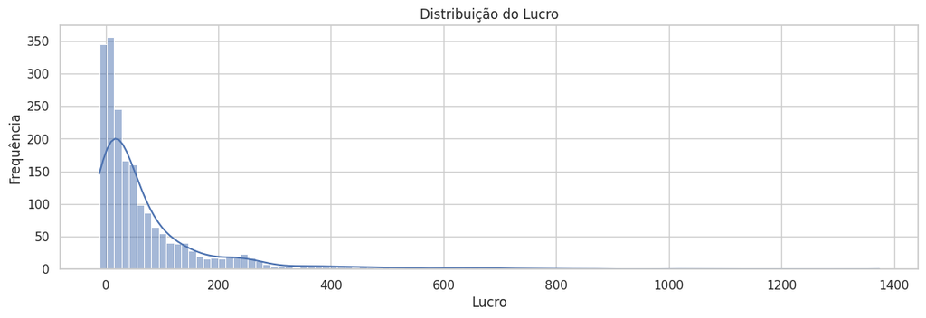

```python
# Distribuição frequência por lucro
sns.histplot(
    data=data,
    x="Profit",
    kde=True,
)

plt.title("Distribuição do Lucro")
plt.xlabel("Lucro")
plt.ylabel("Frequência")

plt.show()
```

## 10. Quantas vendas são lucrativas?

Agora criamos nossa variável-alvo - "data["Profit_Class]"

```python
# Interpretação:
# "Profit > 0 = Rentável"
# "Profit < 0 = Não Rentável"
data["Profit_Class"] = (
    data["Profit"] > 0
).astype(int)
```

## 11. Distribuição das classes

```python
data["Profit_Class"].value_counts()
```

```
Profit_Class
1    1728
0     272
Name: count, dtype: int64
```

```python
# Percentual
data["Profit_Class"].value_counts(
    normalize=True
).mul(100)
```

```
Profit_Class
1    86.4
0    13.6
Name: proportion, dtype: float64
```

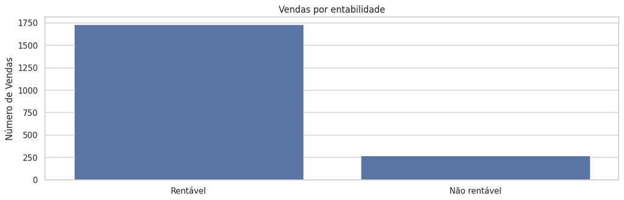

```python
class_labels = {
    0: "Não rentável",
    1: "Rentável",
}

plot_data = data.copy()

plot_data["Profitability"] = (
    plot_data["Profit_Class"]
    .map(class_labels)
)

sns.countplot(
    data=plot_data,
    x="Profitability",
)

plt.title("Vendas por entabilidade")
plt.xlabel("")
plt.ylabel("Número de Vendas")

plt.show()
```

## 12. EDA — Desconto × lucro

Existe relação entre desconto e lucro?

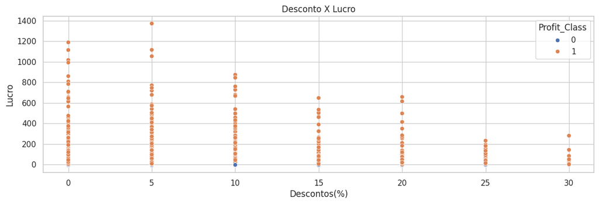

```python
sns.scatterplot(
    data=data,
    x="Discount_Percent",
    y="Profit",
    hue="Profit_Class",
)

plt.title("Desconto X Lucro")
plt.xlabel("Descontos(%)")
plt.ylabel("Lucro")

plt.show()
```

```python
# Correlação descontos X lucro
data[
    [
        "Discount_Percent",
        "Profit",
    ]
].corr()
```

|  | Discount_Percent | Profit |
| --- | --- | --- |
| Discount_Percent | 1.00000 | -0.14134 |
| Profit | -0.14134 | 1.00000 |

## 13. Rentabilidade por categoria

```python
category_profit = (
    data.groupby("Product_Category")["Profit"]
    .sum()
    .sort_values()
)

category_profit
```

```
Product_Category
Office Supplies            3319.16
Clothing & Accessories    26112.94
Technology                48268.65
Furniture                 81171.57
Name: Profit, dtype: float64
```

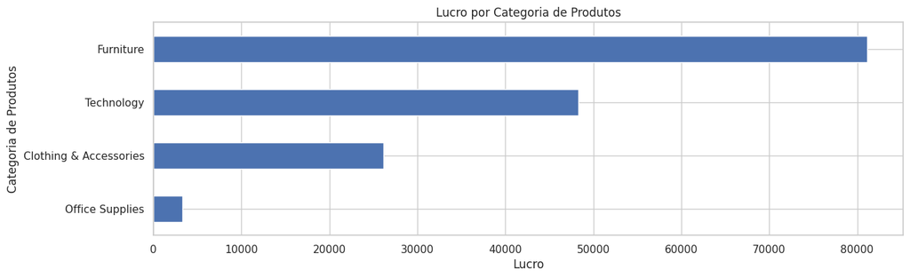

```python
category_profit.plot(
    kind="barh",
)

plt.title("Lucro por Categoria de Produtos")
plt.xlabel("Lucro")
plt.ylabel("Categoria de Produtos")

plt.show()
```

## 14. Rentabilidade por região

```python
region_profit = (
    data.groupby("Region")["Profit"]
    .sum()
    .sort_values()
)

region_profit
```

```
Region
Middle East & Africa    14152.48
South America           14680.98
Asia Pacific            39116.61
North America           45250.09
Europe                  45672.16
Name: Profit, dtype: float64
```

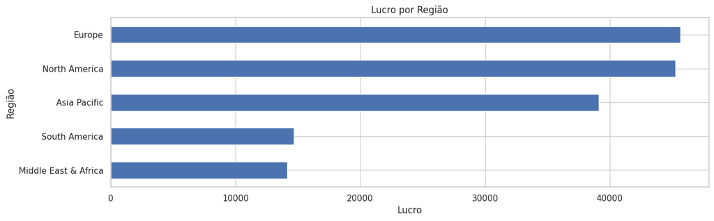

```python
region_profit.plot(
    kind="barh",
)

plt.title("Lucro por Região")
plt.xlabel("Lucro")
plt.ylabel("Região")

plt.show()
```

## 15. Rentabilidade por segmento

```python
segment_profit = (
    data.groupby("Customer_Segment")["Profit"]
    .sum()
    .sort_values()
)

segment_profit
```

```
Customer_Segment
Home Office    27108.52
Corporate      44463.44
Consumer       87300.36
Name: Profit, dtype: float64
```

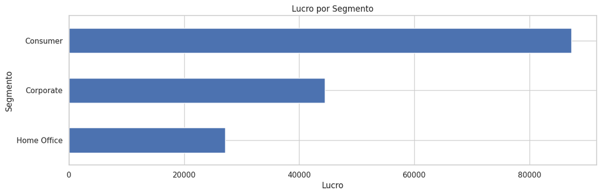

```python
segment_profit.plot(
    kind="barh",
)

plt.title("Lucro por Segmento")
plt.xlabel("Lucro")
plt.ylabel("Segmento")

plt.show()
```

## 16. Frete X lucro

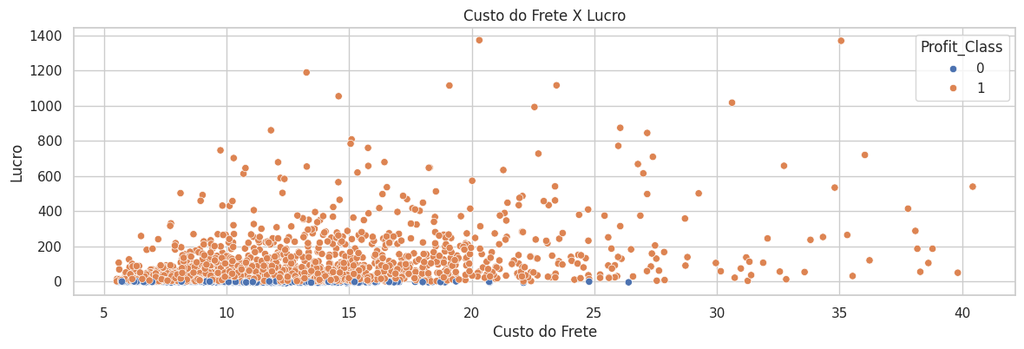

```python
sns.scatterplot(
    data=data,
    x="Shipping_Cost",
    y="Profit",
    hue="Profit_Class",
)

plt.title("Custo do Frete X Lucro")
plt.xlabel("Custo do Frete")
plt.ylabel("Lucro")

plt.show()
```

## 17. Engenharia de Atributos

Criação de variáveis que podem ser conhecidas antes ou no momento da venda.

```python
# Receita bruta
data["Gross_Value"] = (
    data["Quantity"] *
    data["Unit_Price"]
)
# Descontos
data["Discount_Value"] = (
    data["Gross_Value"]
    * data["Discount_Percent"]
    / 100
)
# Receita líquida
data["Net_Sales_Estimated"] = (
    data["Gross_Value"]
    - data["Discount_Value"]
)
# Ano das vendas
data["Order_Year"] = (
    data["Order_Date"].dt.year
)
# Mês das vendas
data["Order_Month"] = (
    data["Order_Date"].dt.month
)
# Tremestre das vendas
data["Order_Quarter"] = (
    data["Order_Date"].dt.quarter
)
# Dia das vendas
data["Order_DayOfWeek"] = (
    data["Order_Date"].dt.dayofweek
)
```

## 18. Data Leakage

Esta é uma das partes mais importantes do notebook.

```python
# Define a variável que o modelo deve prever,
target = "Profit_Class"

# Colunas a serem removidas:
# - Profit → é removido porque foi usado para criar Profit_Class. Mantê-lo causaria
# data leakage(vazamento de dados), pois o modelo teria acesso à informação que originou o próprio alvo.
# - Profit_Class → também é removido das features porque é justamente aquilo que queremos prever.
# - Order_ID → é removido porque é apenas um identificador do pedido e não representa uma
# característica útil para prever a classe de lucro
features_to_remove = [
    "Profit",
    "Profit_Class",
    "Order_ID",
]
```

## 19. Definindo X e y

```python
# Remove a lista já criada.
X = data.drop(
    columns=features_to_remove
)

# Insere a variável alvo em y.
y = data[target]
```

## 20. Definindo tipos de features

```python
# Numéricas:
numeric_features = [
    "Quantity",
    "Unit_Price",
    "Discount_Percent",
    "Total_Sales",
    "Shipping_Cost",
    "Gross_Value",
    "Discount_Value",
    "Net_Sales_Estimated",
    "Order_Year",
    "Order_Month",
    "Order_Quarter",
    "Order_DayOfWeek",
]

# Categóricas
categorical_features = [
    "Customer_Segment",
    "Country",
    "Region",
    "Product_Category",
    "Product_Name",
    "Payment_Method",
]
```

## 21. Train/Test Split

```python
# Define as variáveis de treinamento e teste:
# X: features.
# y: target.
# test_size=0.20: 20% → teste e 80% → treinamento.
# random_state=42 → Define uma semente para operações que envolvem aleatoriedade.
# stratify=y: mantém uma proporção semelhante das classes nos dois conjuntos.
X_train, X_test, y_train, y_test = train_test_split(
    X,
    y,
    test_size=0.20,
    random_state=42,
    stratify=y,
)
```

## 21. Pipeline de pré-processamento

```python
# - Esse trecho cria dois pipelines de pré-processamento: um para
# variáveis numéricas e outro para variáveis categóricas.
# - PIPELINE NUMÉRICO:
# - SimpleImputer(strategy="median") → preenche valores ausentes
# usando a mediana da coluna.
# - StandardScaler() → padroniza os valores numéricos, deixando as
# variáveis em uma escala comparável, com média próxima de 0 e
# desvio padrão próximo de 1.
# - PIPELINE CATEGÓRICO:
# - SimpleImputer(strategy="most_frequent") → preenche valores
# ausentes usando o valor mais frequente da coluna.
# - OneHotEncoder(handle_unknown="ignore") → transforma categorias
# em variáveis numéricas (0 e 1).
numeric_pipeline = Pipeline(
    steps=[
        (
            "imputer",
            SimpleImputer(
                strategy="median"
            ),
        ),
        (
            "scaler",
            StandardScaler(),
        ),
    ]
)

categorical_pipeline = Pipeline(
    steps=[
        (
            "imputer",
            SimpleImputer(
                strategy="most_frequent"
            ),
        ),
        (
            "encoder",
            OneHotEncoder(
                handle_unknown="ignore"
            ),
        ),
    ]
)
```

## 22. ColumnTransformer

Agora temos um único objeto responsável pelo pré-processamento - preprocessor.

```python
# Esse trecho cria o pré-processador principal do projeto.
# Ele determina como cada tipo de variável será tratado
# antes de chegar ao modelo de Machine Learning.
# - ColumnTransformer → Permite aplicar tratamentos
# diferentes para diferentes grupos de colunas
# - "numeric" → Para as colunas listadas em numeric_features, utilize o numeric_pipeline.
# - "categorical" → Para as colunas listadas em categorical_features, utilize o categorical_pipeline.
preprocessor = ColumnTransformer(
    transformers=[
        (
            "numeric",
            numeric_pipeline,
            numeric_features,
        ),
        (
            "categorical",
            categorical_pipeline,
            categorical_features,
        ),
    ]
)
```

## 23. Baseline

Antes de treinar modelos sofisticados, precisamos de uma referência.

```python
# - Esse trecho cria um modelo de referência (baseline) para comparar
# posteriormente com os modelos de classificação, como
# LogisticRegression, DecisionTree ou RandomForest.
# - Pipeline(...) → junta várias etapas em um único fluxo.
# - "preprocessor" → executa o pré-processamento que você definiu anteriormente, como:
# * preenchimento de valores ausentes;
# * padronização das variáveis numéricas;
# * codificação das variáveis categóricas.
# - "classifier" → define o algoritmo responsável pela classificação.
# - DummyClassifier(...) → cria um classificador muito simples, usado apenas como referência.
# - strategy="most_frequent" → o modelo sempre prevê a classe mais frequente do conjunto de treinamento
baseline = Pipeline(
    steps=[
        (
            "preprocessor",
            preprocessor,
        ),
        (
            "classifier",
            DummyClassifier(
                strategy="most_frequent"
            ),
        ),
    ]
)
```

```python
# Treinamento
baseline.fit(
    X_train,
    y_train,
)
```

```
Pipeline(steps=[('preprocessor',
                 ColumnTransformer(transformers=[('numeric',
                                                  Pipeline(steps=[('imputer',
                                                                   SimpleImputer(strategy='median')),
                                                                  ('scaler',
                                                                   StandardScaler())]),
                                                  ['Quantity', 'Unit_Price',
                                                   'Discount_Percent',
                                                   'Total_Sales',
                                                   'Shipping_Cost',
                                                   'Gross_Value',
                                                   'Discount_Value',
                                                   'Net_Sales_Estimated',
                                                   'Order_Year', 'Order_Month',
                                                   'Order_Quarter',
                                                   'Order_DayOfWeek']),
                                                 ('categorical',
                                                  Pipeline(steps=[('imputer',
                                                                   SimpleImputer(strategy='most_frequent')),
                                                                  ('encoder',
                                                                   OneHotEncoder(handle_unknown='ignore'))]),
                                                  ['Customer_Segment',
                                                   'Country', 'Region',
                                                   'Product_Category',
                                                   'Product_Name',
                                                   'Payment_Method'])])),
                ('classifier', DummyClassifier(strategy='most_frequent'))])
```

```python
# Predição
baseline_pred = baseline.predict(
    X_test
)
```

```python
# Avaliação
baseline_accuracy = accuracy_score(
    y_test,
    baseline_pred,
)

baseline_accuracy
```

```
0.865
```

## 24. Modelo 1 — Logistic Regression

```python
#  Logistic Regression (Regressão Logística)
# - O que é: Um modelo estatístico e linear usado para prever a probabilidade
# de um evento binário acontecer (como sim/não, 0/1, aprovado/reprovado).
# - Como funciona: Utiliza uma função matemática chamada sigmoide para mapear
# qualquer valor de entrada em uma probabilidade entre 0 e 1. Se o resultado
# for maior que 0,5, por exemplo, o modelo classifica como "1"; caso contrário, como "0".
# - Vantagens: É extremamente rápido, simples de implementar e muito fácil de
# interpretar para dados com relações lineares.
# - Limitações: Assume uma relação linear entre as variáveis e pode ter
# um desempenho fraco em problemas complexos ou não lineares.

# Esse trecho cria um pipeline completo de classificação usando Regressão
# Logística. Ele combina o pré-processamento dos dados com o modelo,
# garantindo que as etapas sejam executadas na ordem correta.
# - logistic_model = Pipeline(...) → Cria um fluxo único para o modelo.
# - preprocessor → Aplica o preprocessor definido anteriormente.
# - classifier:
# * LogisticRegression é um modelo utilizado para classificação,
# neste caso para prever: Profit_Class.
# * max_iter=1000 → Define o número máximo de iterações permitidas
# para o algoritmo encontrar os parâmetros do modelo.
# * random_state=42 → Define uma semente para operações que envolvem aleatoriedade.
logistic_model = Pipeline(
    steps=[
        (
            "preprocessor",
            preprocessor,
        ),
        (
            "classifier",
            LogisticRegression(
                max_iter=1000,
                random_state=42,
            ),
        ),
    ]
)
```

```python
# Treinamento
logistic_model.fit(
    X_train,
    y_train,
)
```

```
Pipeline(steps=[('preprocessor',
                 ColumnTransformer(transformers=[('numeric',
                                                  Pipeline(steps=[('imputer',
                                                                   SimpleImputer(strategy='median')),
                                                                  ('scaler',
                                                                   StandardScaler())]),
                                                  ['Quantity', 'Unit_Price',
                                                   'Discount_Percent',
                                                   'Total_Sales',
                                                   'Shipping_Cost',
                                                   'Gross_Value',
                                                   'Discount_Value',
                                                   'Net_Sales_Estimated',
                                                   'Order_Year', 'Order_Month',
                                                   'Order_Quarter',
                                                   'Order_DayOfWeek']),
                                                 ('categorical',
                                                  Pipeline(steps=[('imputer',
                                                                   SimpleImputer(strategy='most_frequent')),
                                                                  ('encoder',
                                                                   OneHotEncoder(handle_unknown='ignore'))]),
                                                  ['Customer_Segment',
                                                   'Country', 'Region',
                                                   'Product_Category',
                                                   'Product_Name',
                                                   'Payment_Method'])])),
                ('classifier',
                 LogisticRegression(max_iter=1000, random_state=42))])
```

## 25. Modelo 2 — Decision Tree

```python
# Decision Tree (Árvore de Decisão)
# - O que é: Um modelo em formato de fluxograma ou árvore invertida que
# toma decisões baseadas em regras de perguntas "se/então" (if-else).
# - Como funciona: O algoritmo divide os dados recursivamente com base em
# características específicas (usando métricas como impureza de Gini
# ou ganho de informação) até chegar a uma conclusão final nas "folhas" da árvore.
# - Vantagens: Altamente intuitivo, fácil de visualizar e capaz de lidar
# com dados numéricos e categóricos sem exigências complexas de pré-processamento.
# Limitações: Sofre facilmente de overfitting (quando decora os dados de treino
# e generaliza mal para novos dados) e pode ser instável, pois uma pequena
# mudança nos dados pode alterar toda a estrutura da árvore.

# - Esse trecho cria um pipeline de classificação utilizando uma
# Árvore de Decisão (DecisionTreeClassifier).
# tree_model = Pipeline(...) → Cria um fluxo único.
# - preprocessor → Aplica o pré-processamento definido anteriormente.
# - DecisionTreeClassifier → Algoritmo que fará a classificação de Profit_Class.
# - max_depth=6 → Limita a profundidade máxima da árvore a 6 níveis.
# - random_state=42 → Define uma semente para garantir maior reprodutibilidade
# dos resultados.
tree_model = Pipeline(
    steps=[
        (
            "preprocessor",
            preprocessor,
        ),
        (
            "classifier",
            DecisionTreeClassifier(
                max_depth=6,
                random_state=42,
            ),
        ),
    ]
)
```

## 26. Modelo 3 — Random Forest

```python
#  Random Forest (Floresta Aleatória)
# O que é: Um método de aprendizado em conjunto (ensemble) que cria várias
# árvores de decisão durante o treinamento e combina os resultados delas.
# Como funciona: Cada árvore é treinada em uma parte aleatória dos dados e
# usando um subconjunto aleatório de características (feature bagging).
# Para a previsão final, o modelo faz uma votação majoritária (em classificação)
# ou tira a média (em regressão).
# Vantagens: Muito mais robusto e preciso do que uma única árvore de decisão,
# além de ser altamente resistente a ruídos e menos propenso a overfitting.
# Limitações: É mais complexo de interpretar do que um modelo linear
# único e exige mais poder computacional e tempo de treinamento.

# - Esse trecho cria o pipeline do modelo Random Forest,
# que será usado para prever a variável Profit_Class
# - forest_model = Pipeline(...) → Cria um fluxo único.
# - preprocessor → Utiliza o ColumnTransformer criado anteriormente.
# - RandomForestClassifier → O Random Forest combina várias árvores
# de decisão para produzir uma previsão mais robusta.
# - n_estimators=300 → Define que o modelo utilizará 300 árvores de decisão.
# - max_depth=10 → Define a profundidade máxima de cada árvore.
# - random_state=42 → Define uma semente para tornar os resultados reproduzíveis.
# - n_jobs=-1 → Indica que o modelo pode utilizar todos os núcleos de CPU
# disponíveis para executar o processamento em paralelo.
forest_model = Pipeline(
    steps=[
        (
            "preprocessor",
            preprocessor,
        ),
        (
            "classifier",
            RandomForestClassifier(
                n_estimators=300,
                max_depth=10,
                random_state=42,
                n_jobs=-1,
            ),
        ),
    ]
)
```

```python
# Treinamento
forest_model.fit(
    X_train,
    y_train,
)
```

```
Pipeline(steps=[('preprocessor',
                 ColumnTransformer(transformers=[('numeric',
                                                  Pipeline(steps=[('imputer',
                                                                   SimpleImputer(strategy='median')),
                                                                  ('scaler',
                                                                   StandardScaler())]),
                                                  ['Quantity', 'Unit_Price',
                                                   'Discount_Percent',
                                                   'Total_Sales',
                                                   'Shipping_Cost',
                                                   'Gross_Value',
                                                   'Discount_Value',
                                                   'Net_Sales_Estimated',
                                                   'Order_Year', 'Order_Month',
                                                   'Order_Quarter',
                                                   'Order_DayOfWeek']),
                                                 ('categorical',
                                                  Pipeline(steps=[('imputer',
                                                                   SimpleImputer(strategy='most_frequent')),
                                                                  ('encoder',
                                                                   OneHotEncoder(handle_unknown='ignore'))]),
                                                  ['Customer_Segment',
                                                   'Country', 'Region',
                                                   'Product_Category',
                                                   'Product_Name',
                                                   'Payment_Method'])])),
                ('classifier',
                 RandomForestClassifier(max_depth=10, n_estimators=300,
                                        n_jobs=-1, random_state=42))])
```

## 27. Avaliação dos modelos

Vamos criar uma função para evitar repetir código.

```python
def evaluate_model(
    model,
    X_test,
    y_test,
) -> dict[str, float]:
    """
    Avalie um modelo de classificação binária

    Args:
        model: Modelo de classificação treinado.
        X_test: Teste features.
        y_test: Teste target.

    Returns:
        Dicionário contendo métricas de classificação.
    """

    predictions = model.predict(X_test)

    probabilities = model.predict_proba(
        X_test
    )[:, 1]

    return {
        "Accuracy": accuracy_score(
            y_test,
            predictions,
        ),
        "Precision": precision_score(
            y_test,
            predictions,
            zero_division=0,
        ),
        "Recall": recall_score(
            y_test,
            predictions,
            zero_division=0,
        ),
        "F1": f1_score(
            y_test,
            predictions,
            zero_division=0,
        ),
        "ROC-AUC": roc_auc_score(
            y_test,
            probabilities,
        ),
    }
```

## 28. Comparando os modelos

```python
# Dicionário de modelos.
models = {
    "Logistic Regression": logistic_model,
    "Decision Tree": tree_model,
    "Random Forest": forest_model,
}
```

```python
results = []

for name, model in models.items():

    model.fit(
        X_train,
        y_train,
    )

    metrics = evaluate_model(
        model,
        X_test,
        y_test,
    )

    metrics["Model"] = name

    results.append(metrics)
```

```python
# Criamos um DataFrame:
results_df = pd.DataFrame(
    results
)

results_df = results_df[
    [
        "Model",
        "Accuracy",
        "Precision",
        "Recall",
        "F1",
        "ROC-AUC",
    ]
]

results_df.sort_values(
    "F1",
    ascending=False,
)
```

|  | Model | Accuracy | Precision | Recall | F1 | ROC-AUC |
| --- | --- | --- | --- | --- | --- | --- |
| 2 | Random Forest | 0.9825 | 0.985673 | 0.994220 | 0.989928 | 0.994434 |
| 1 | Decision Tree | 0.9725 | 0.977208 | 0.991329 | 0.984218 | 0.973025 |
| 0 | Logistic Regression | 0.9400 | 0.965318 | 0.965318 | 0.965318 | 0.980518 |

Os resultados demonstram desempenho elevado nos três modelos avaliados. O Random Forest apresentou os maiores valores nas métricas analisadas, com 98,25% de Accuracy, 98,57% de Precision, 99,42% de Recall, 98,99% de F1-score e 99,44% de ROC-AUC. A Decision Tree também apresentou desempenho elevado, enquanto a Logistic Regression apresentou valores inferiores nas métricas de classificação. Esses resultados indicam que os modelos conseguiram distinguir as classes de Profit_Class com elevada capacidade preditiva no conjunto de teste.

## 29. Classification Report

Vamos analisar o Random Forest, por exemplo:

```python
forest_predictions = forest_model.predict(
    X_test
)

print(
    classification_report(
        y_test,
        forest_predictions,
        target_names=[
            "Non-profitable",
            "Profitable",
        ],
        zero_division=0,
    )
)
```

```
                precision    recall  f1-score   support

Non-profitable       0.96      0.91      0.93        54
    Profitable       0.99      0.99      0.99       346

      accuracy                           0.98       400
     macro avg       0.97      0.95      0.96       400
  weighted avg       0.98      0.98      0.98       400
```

O Random Forest apresentou desempenho elevado, com 98% de acurácia no conjunto de teste. Para a classe Profitable, o modelo alcançou 99% de precision, recall e F1-score, demonstrando alta capacidade de identificação dos casos lucrativos. Para Non-profitable, apresentou 96% de precision, 91% de recall e 93% de F1-score. A diferença entre as classes está relacionada também à distribuição dos dados, que possui 346 registros lucrativos contra 54 não lucrativos.

## 30. Matriz de confusão

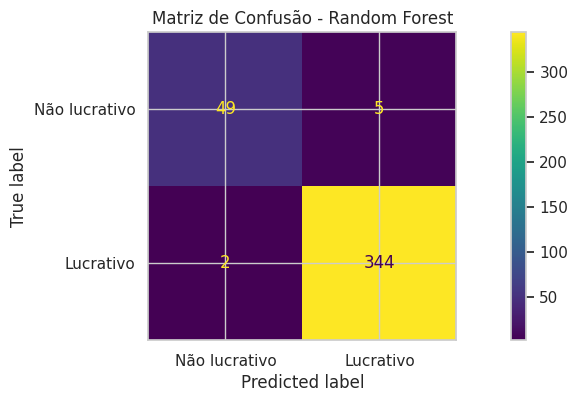

```python
cm = confusion_matrix(
    y_test,
    forest_predictions,
)

disp = ConfusionMatrixDisplay(
    confusion_matrix=cm,
    display_labels=[
        "Não lucrativo",
        "Lucrativo",
    ],
)

disp.plot()

plt.title(
    "Matriz de Confusão - Random Forest"
)

plt.show()
```

O modelo apresenta excelente desempenho global, acertando 98,25% de todas as previsões. Ele é particularmente forte na detecção da classe Lucrativo, falhando em apenas 2 dos 346 casos reais desta categoria. A proporção de falsos alarmes (5 casos de Não lucrativo previstos como Lucrativo) também é baixa, o que indica alta confiabilidade nas previsões do algoritmo.

## 31. ROC-AUC

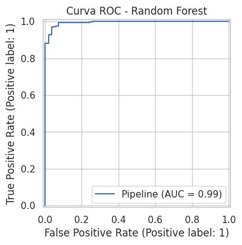

```python
RocCurveDisplay.from_estimator(
    forest_model,
    X_test,
    y_test,
)

plt.title(
    "Curva ROC - Random Forest"
)

plt.show()
```

O comportamento da curva subindo quase verticalmente até próximo de 1.0 no Eixo Y enquanto se mantém muito próxima do 0.0 no Eixo X indica que o algoritmo consegue identificar a grande maioria dos casos positivos (Lucrativos) cometendo raríssimos falsos alarmes, independentemente do limiar ajustado.

## 32. Validação cruzada

Agora vamos além de uma única divisão treino/teste

```python
cv = StratifiedKFold(
    n_splits=5,
    shuffle=True,
    random_state=42,
)
```

```python
# Vamos avaliar o Random Forest:
cv_results = cross_validate(
    forest_model,
    X,
    y,
    cv=cv,
    scoring=[
        "accuracy",
        "precision",
        "recall",
        "f1",
        "roc_auc",
    ],
    n_jobs=-1,
)
```

```python
# Resultados:
for metric in [
    "test_accuracy",
    "test_precision",
    "test_recall",
    "test_f1",
    "test_roc_auc",
]:

    print(
        f"{metric}: "
        f"{cv_results[metric].mean():.4f} "
        f"+/- "
        f"{cv_results[metric].std():.4f}"
    )
```

```
test_accuracy: 0.9710 +/- 0.0041
test_precision: 0.9816 +/- 0.0033
test_recall: 0.9850 +/- 0.0064
test_f1: 0.9832 +/- 0.0024
test_roc_auc: 0.9913 +/- 0.0020
```

A validação cruzada apresentou resultados consistentes para o modelo, com Accuracy de 97,10%, Precision de 98,16%, Recall de 98,50%, F1 de 98,32% e ROC-AUC de 99,13%. Os valores após ± representam a variação dos resultados entre as diferentes divisões dos dados. Como essas variações são relativamente pequenas, os resultados indicam boa estabilidade e consistência do modelo nas diferentes amostras avaliadas.

## 33. Variáveis importantes

Agora queremos descobrir:

Quais variáveis mais contribuíram para as decisões do Random Forest?

```python
fitted_preprocessor = (
    forest_model
    .named_steps["preprocessor"]
)
```

```python
# Obtemos os nomes:
feature_names = (
    fitted_preprocessor
    .get_feature_names_out()
)
```

```python
#Importâncias:
forest_classifier = (
    forest_model
    .named_steps["classifier"]
)

importance = pd.Series(
    forest_classifier.feature_importances_,
    index=feature_names,
)
```

```python
# Ordenando:
importance = importance.sort_values(
    ascending=False
)
```

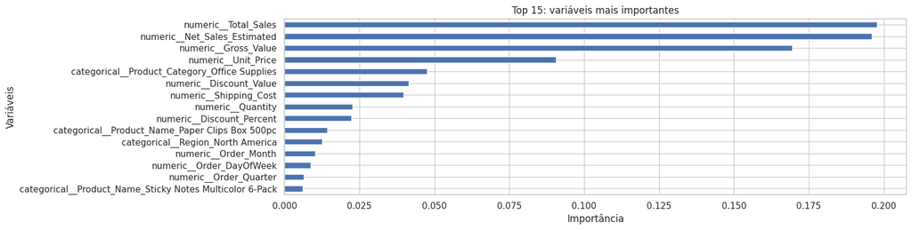

```python
# Visualizando as 15 principais:
importance.head(15).sort_values().plot(
    kind="barh"
)

plt.title(
    "Top 15: variáveis mais importantes"
)

plt.xlabel(
    "Importância"
)

plt.ylabel(
    "Variáveis"
)

plt.show()
```

## Interpretação da Importância das Variáveis

A análise da importância das variáveis ajuda a identificar quais delas exerceram maior influência na classificação do modelo Random Forest.

Essas variáveis não devem ser interpretadas automaticamente como fatores de causalidade.

Em vez disso, elas indicam quais variáveis mais contribuíram para as decisões preditivas do modelo.

Portanto, a interpretação sob a ótica do negócio deve ser combinada com a análise descritiva e o conhecimento do domínio.

## 34. Análise de erros

Agora queremos descobrir:

Onde o modelo erra?

```python
test_results = X_test.copy()

test_results["Actual"] = y_test

test_results["Predicted"] = (
    forest_model.predict(X_test)
)
```

```python
# Filtrando os erros:
errors = test_results[
    test_results["Actual"]
    != test_results["Predicted"]
]

errors.head()
```

|  | Order_Date | Customer_Name | Customer_Segment | Country | Region | Product_Category | Product_Name | Quantity | Unit_Price | Discount_Percent | Total_Sales | Shipping_Cost | Payment_Method | Gross_Value | Discount_Value | Net_Sales_Estimated | Order_Year | Order_Month | Order_Quarter | Order_DayOfWeek | Actual | Predicted |
| --- | --- | --- | --- | --- | --- | --- | --- | --- | --- | --- | --- | --- | --- | --- | --- | --- | --- | --- | --- | --- | --- | --- |
| 1901 | 2025-11-11 | Sophie Zhang | Consumer | Mexico | North America | Office Supplies | Paper Clips Box 500pc | 2 | 7.54 | 0 | 15.08 | 6.17 | Credit Card | 15.08 | 0.0000 | 15.0800 | 2025 | 11 | 4 | 1 | 1 | 0 |
| 1311 | 2024-12-25 | Mary Clark | Consumer | United States | North America | Office Supplies | Binder Clips Assorted 48pc | 3 | 13.27 | 25 | 29.86 | 12.34 | Credit Card | 39.81 | 9.9525 | 29.8575 | 2024 | 12 | 4 | 2 | 0 | 1 |
| 786 | 2024-03-27 | Ava Clark | Corporate | Nigeria | Middle East & Africa | Technology | Wireless Ergonomic Mouse | 2 | 21.45 | 15 | 36.46 | 13.62 | Credit Card | 42.90 | 6.4350 | 36.4650 | 2024 | 3 | 1 | 2 | 0 | 1 |
| 661 | 2023-12-26 | Isabella Anderson | Corporate | South Korea | Asia Pacific | Technology | USB-C Hub Multiport Adapter | 1 | 53.57 | 25 | 40.18 | 11.21 | Cash on Delivery | 53.57 | 13.3925 | 40.1775 | 2023 | 12 | 4 | 1 | 0 | 1 |
| 1029 | 2024-08-05 | Layla Zhang | Corporate | United States | North America | Office Supplies | Stapler Full-Size | 2 | 7.92 | 0 | 15.84 | 8.07 | PayPal | 15.84 | 0.0000 | 15.8400 | 2024 | 8 | 3 | 0 | 1 | 0 |

A análise de erros apresenta os registros em que o Random Forest classificou incorretamente a Profit_Class. Os exemplos mostram tanto falsos positivos quanto falsos negativos, indicando que algumas combinações de preço, desconto, quantidade, vendas e custos podem dificultar a classificação. Essa análise é importante para identificar padrões nos erros do modelo e compreender em quais tipos de pedidos a previsão apresenta maior dificuldade.

```python
# Quantidade de erros
len(errors)
```

```
7
```

## 35. Erros por região

```python
errors_by_region = (
    errors
    .groupby("Region")
    .size()
    .sort_values(
        ascending=False
    )
)

errors_by_region
```

```
Region
North America           4
Asia Pacific            2
Middle East & Africa    1
dtype: int64
```

## 36. Erros por categoria

```python
errors_by_category = (
    errors
    .groupby("Product_Category")
    .size()
    .sort_values(
        ascending=False
    )
)

errors_by_category
```

```
Product_Category
Office Supplies    5
Technology         2
dtype: int64
```

## 37. Erros por desconto

```python
errors[
    "Discount_Percent"
].describe()
```

```
count     7.000000
mean     12.857143
std      12.535663
min       0.000000
25%       0.000000
50%      15.000000
75%      25.000000
max      25.000000
Name: Discount_Percent, dtype: float64
```

```python
# Você pode comparar com todas as vendas:
comparison = pd.DataFrame({
    "All Sales": data[
        "Discount_Percent"
    ].describe(),

    "Classification Errors": errors[
        "Discount_Percent"
    ].describe(),
})

comparison
```

|  | All Sales | Classification Errors |
| --- | --- | --- |
| count | 2000.000000 | 7.000000 |
| mean | 8.572500 | 12.857143 |
| std | 7.261274 | 12.535663 |
| min | 0.000000 | 0.000000 |
| 25% | 0.000000 | 0.000000 |
| 50% | 10.000000 | 15.000000 |
| 75% | 15.000000 | 25.000000 |
| max | 30.000000 | 25.000000 |

## 38. Predição de uma nova venda

Agora vamos simular uma venda.

```python
new_sale = pd.DataFrame({
    "Customer_Segment": ["Corporate"],
    "Country": ["United States"],
    "Region": ["West"],
    "Product_Category": ["Technology"],
    "Product_Name": ["Laptop"],
    "Quantity": [5],
    "Unit_Price": [1200],
    "Discount_Percent": [10],
    "Total_Sales": [5400],
    "Shipping_Cost": [150],
    "Payment_Method": ["Credit Card"],
    "Gross_Value": [6000],
    "Discount_Value": [600],
    "Net_Sales_Estimated": [5400],
    "Order_Year": [2026],
    "Order_Month": [9],
    "Order_Quarter": [3],
    "Order_DayOfWeek": [0],
})
```

```python
# Predição:
prediction = forest_model.predict(
    new_sale
)

probability = forest_model.predict_proba(
    new_sale
)[:, 1]
```

```python
# Resultado:
print(
    "Predição:",
    "Lucrátiva"
    if prediction[0] == 1
    else "Non-profitable",
)

print(
    f"Probabilidade de Lucratividade: "
    f"{probability[0]:.2%}"
)
```

```
Predição: Lucrátiva
Probabilidade de Lucratividade: 99.65%
```

## 39. Conclusão do notebook

Este projeto desenvolveu um pipeline completo de aprendizado de máquina supervisionado para a classificação da rentabilidade de vendas.

A análise incluiu:

- Avaliação da qualidade dos dados
- Análise Exploratória de Dados
- Engenharia da variável-alvo
- Engenharia de atributos (features)
- Prevenção de vazamento de dados (data leakage)
- Pré-processamento de variáveis numéricas e categóricas
- Modelagem de referência (baseline)
- Regressão Logística
- Árvore de Decisão
- Random Forest
- Validação cruzada
- Métricas de classificação
- Matriz de confusão
- Análise ROC-AUC
- Importância dos atributos
- Análise de erros

Os resultados demonstram como o aprendizado de máquina pode ser aplicado para classificar vendas de acordo com a lucratividade, utilizando características comerciais, do cliente, do produto, geográficas e operacionais.

O modelo pode ser utilizado como um componente de suporte à decisão para análises adicionais da lucratividade de vendas.

No entanto, o desempenho preditivo deve ser continuamente validado com novos dados antes de se considerar a implementação em produção.

## 40. Diagrama de fluxo

```
┌─────────────────────────────┐
│      DATASET DE VENDAS      │
└──────────────┬──────────────┘
               ↓
┌─────────────────────────────┐
│   ENTENDIMENTO DOS DADOS    │
│ shape / types / estatística │
└──────────────┬──────────────┘
               ↓
┌─────────────────────────────┐
│     QUALIDADE DOS DADOS     │
│ ausentes / duplicados / etc.│
└──────────────┬──────────────┘
               ↓
┌─────────────────────────────┐
│             EDA             │
│  Lucro / Desconto / Região  │
│  Categorias / Frete / etc.  │
└──────────────┬──────────────┘
               ↓
┌─────────────────────────────┐
│      CRIAÇÃO do TARGET      │
│ Lucro > 0 → 1               │
│ Lucro <= 0 → 0              │
└──────────────┬──────────────┘
               ↓
┌──────────────────────────────┐
│CONTROLE DO VAZAMENTO DE DADOS│
│  Remover Lucro(Profit) de X  │
└──────────────┬───────────────┘
               ↓
┌─────────────────────────────┐
│   ENGENHARIA DE ATRIBUTOS   │
│ Desconto / Temporal / etc.  │
└──────────────┬──────────────┘
               ↓
┌─────────────────────────────┐
│       TREINO / TESTE        │
│         80% / 20%           │
└──────────────┬──────────────┘
               ↓
┌─────────────────────────────┐
│        PROCESSAMENTO        │
│    Numérico + Categórico    │
└──────────────┬──────────────┘
               ↓
       ┌───────┼────────┐
       ↓       ↓        ↓
   Logistic   Tree    Forest
       │       │        │
       └───────┼────────┘
               ↓
┌─────────────────────────────┐
│         AVSLIAÇÃO           │
│ Accuracy / Precision        │
│ Recall / F1 / ROC-AUC       │
└──────────────┬──────────────┘
               ↓
┌─────────────────────────────┐
│       ANÁLISE DE ERROS      │
│Região / Categoria / Desconto│
└──────────────┬──────────────┘
               ↓
┌─────────────────────────────┐
│   INSIGHTS DE NEGÓCIOS      │
└──────────────┬──────────────┘
               ↓
┌─────────────────────────────┐
│          CONCLUSÃO          │
└─────────────────────────────┘
```

## Autor:

- Autor: Carlos da Costa
- Recife, PE - Brasil
- Telefone: +55 81 99712 9140
- Telegram: @jcarlossc
- Blogger linguagem R: https://informaticus77-r.blogspot.com/
- Blogger linguagem Python: https://informaticus77-python.blogspot.com/
- Email: jcarlossc1977@gmail.com
- Tableau: https://public.tableau.com/app/profile/carlos.da.costa7416/vizzes/
- LinkedIn: https://www.linkedin.com/in/carlos-da-costa-669252149/
- GitHub: https://github.com/jcarlossc/
- Kaggle: https://www.kaggle.com/jcarlossc/
- Twitter/X: https://x.com/jcarlossc1977/